# Projet de reconnaissance faciale - Document technique - Groupe 1

### Contexte

Notre équipe a été mandatée par l’école d’ingénieurs CESI pour concevoir un système de reconnaissance faciale basé sur l’intelligence artificielle. L’outil sera capable de détecter le visage d’une personne, de reconnaitre une ou plusieurs personnes sur une caméra, et de détecter des objets ou vêtements interdits par le réglement intérieur. Une description des vêtements portés par la personne sera également générée.

### Objectifs

- Identifier chaque étudiant avec un taux de précision d’au moins 85% dans un Proof of Concept (POC) d’ici 4 semaines.
- Produire un dashboard Power BI actualisé quotidiennement intégrant des KPIs cohérents de suivi tel que le temps de pause par élève.
- Détecter les objets interdits par le règlement intérieur avec une précision de 90%.
- Générer un texte descriptif des vêtements portés par la personne.

# Reconnaissance faciale avec TensorFlow

Dans cette cellule, nous importons les bibliothèques nécessaires pour concevoir notre système de reconnaissance faciale. Ces imports couvrent plusieurs aspects du projet, tels que la gestion des données, le traitement des images, l’apprentissage automatique, et la création d’une interface utilisateur.

## Bibliothèques principales

1. **Bibliothèques standards** :
   - Nous utilisons des bibliothèques pour gérer les interactions avec le système, les fichiers, et les formats de données courants (`os`, `sys`, `time`, `json`, `csv`, etc.).
   - Elles nous permettent également de journaliser et de gérer les dates (`logging`, `datetime`).
2. **Interfaces graphiques (GUI)** :
   - Nous utilisons `tkinter` pour créer une interface utilisateur conviviale, avec des boîtes de dialogue et widgets.
3. **Manipulation des données** :
   - `numpy` nous aide à effectuer des traitements numériques et à manipuler des tableaux multidimensionnels.
   - Nous employons `pickle` pour sauvegarder et charger des objets Python.
4. **Traitement d’images** :
   - Nous intégrons `cv2` (OpenCV) pour détecter et manipuler les images.
   - Avec `PIL`, nous gérons divers formats d’images.
5. **Apprentissage profond** :
   - Nous construisons et entraînons nos modèles d’intelligence artificielle avec `tensorflow` et `keras`.
   - Nous utilisons des modèles pré-entraînés (`MobileNetV2`, `DenseNet201`) et des outils pour l’augmentation de données.
6. **Visualisation des résultats** :
   - `matplotlib` nous permet de créer des graphiques.
7. **Divers** :
   - Avec `glob`, nous recherchons des fichiers spécifiques.
   - Nous supprimons les avertissements TensorFlow avec `os.environ['TF_CPP_MIN_LOG_LEVEL']`.

Ces bibliothèques nous offrent tout ce dont nous avons besoin pour développer un système de reconnaissance faciale performant et convivial.

```python
# Standard libraries
import os
import sys
import time
import json
import csv
import logging
import hashlib
from datetime import datetime

# GUI libraries
import tkinter as tk
from tkinter import Tk, Label, filedialog, simpledialog, messagebox, ttk
from textwrap import wrap

# Data manipulation
import numpy as np
import pickle

# Image processing
import cv2
from PIL import Image, ImageTk
from scipy.special import expit

# TensorFlow and Keras
import tensorflow as tf
from tensorflow.keras import layers, models
from tensorflow.keras.utils import img_to_array
from tensorflow.keras.applications import MobileNetV2, DenseNet201
from tensorflow.keras.preprocessing.image import ImageDataGenerator, load_img, img_to_array
from tensorflow.keras.preprocessing.sequence import pad_sequences
from tensorflow.python.keras.callbacks import EarlyStopping

# Plotting
import matplotlib.pyplot as plt

# Miscellaneous
import glob

# Masquer tous les warnings
os.environ['TF_CPP_MIN_LOG_LEVEL'] = '3'  # vous l'avez déjà
```

## Préparation des données

La première étape consiste à préparer les données. Pour cela, nous créons une fonction qui permet de préparer les données nécessaires pour entraîner un modèle de reconnaissance faciale. Elle organise les images en deux groupes : un pour l'entraînement du modèle et un autre pour vérifier si le modèle fonctionne correctement (validation).

### Ce que fait la fonction `prepare_datasets` :

1. **Trouver les classes** :
   - Nous commençons par identifier les différentes catégories (ou classes) dans le dossier principal. Chaque sous-dossier représente une classe, comme "étudiant A" ou "étudiant B".
2. **Charger les images** :
   - Pour chaque classe, nous cherchons toutes les images disponibles.
   - Chaque image est redimensionnée à une taille standard (224x224 pixels) pour qu’elles soient compatibles avec le modèle.
   - Nous transformons également les images en chiffres (valeurs numériques) que l’ordinateur peut comprendre.
3. **Séparer les données** :
   - Nous répartissons les images en deux groupes :
     - Données d’entraînement (3 images sur 5) : utilisées pour apprendre au modèle à reconnaître les visages.
     - Données de validation (2 images sur 5) : utilisées pour vérifier si le modèle a bien appris.
4. **Organiser les données** :
   - Nous regroupons toutes les images et leurs catégories sous forme de tableaux pour faciliter leur utilisation par le modèle.
   - Nous transformons également les catégories (par exemple, "étudiant A" ou "étudiant B") en un format compréhensible par le modèle.
5. **Afficher les classes** :
   - Nous affichons la liste des classes détectées, ce qui permet de vérifier que tout est bien organisé.

### Résultat :

Lorsque cette fonction est exécutée, elle nous renvoie tout ce qu’il faut pour entraîner et tester le modèle :

- Les images et leurs catégories pour l’entraînement.
- Les images et leurs catégories pour la validation.
- La liste des classes détectées.

### Pourquoi c'est important ?

Avant d'entraîner notre modèle d’intelligence artificielle, il faut s’assurer que les données sont bien préparées et organisées. Cette fonction fait tout ce travail automatiquement, ce qui nous permet de nous concentrer sur l’entraînement du modèle.

### Pourquoi 5 photos par étudiant ?

Nous utilisons exactement 5 photos par étudiant, prises sous différents angles :

- Une photo de face
- Une photo regardant vers le haut
- Une photo regardant vers le bas
- Une photo regardant vers la gauche
- Une photo regardant vers la droite

Ce nombre est optimal pour plusieurs raisons :

La sélection de cinq angles clés pour capturer les caractéristiques du visage nous permet une couverture complète des perspectives essentielles, garantissant ainsi une analyse précise et fiable. Ce choix évite l'accumulation inutile de données, car ces angles contiennent déjà toutes les informations distinctives nécessaires, rendant l'apprentissage plus efficace.

De plus, collecter ce nombre raisonnable de photos pour chaque individu est rapide et peu intrusif, ce qui optimise le processus. Enfin, cet équilibre entre quantité et qualité des données nous offre suffisamment d’éléments pour l’entraînement et la validation du modèle tout en réduisant les risques de surapprentissage, assurant des performances optimales.

```python
def prepare_datasets(dataset_path="dataset", img_height=224, img_width=224, train_split=0.6):
    """
    Prépare les datasets d'entraînement et de validation à partir d'un répertoire structuré.

    Arguments :
        dataset_path (str) : chemin vers le dossier contenant les sous-dossiers des classes.
        img_height (int) : hauteur des images après redimensionnement.
        img_width (int) : largeur des images après redimensionnement.
        batch_size (int) : taille des lots (non utilisé ici, mais utile pour le traitement futur).
        train_split (float) : fraction des images utilisées pour l'entraînement.

    Retourne :
        train_images (numpy.ndarray) : tableau des images d'entraînement.
        train_labels (numpy.ndarray) : labels d'entraînement (indices des classes).
        val_images (numpy.ndarray) : tableau des images de validation.
        val_labels (numpy.ndarray) : labels de validation (indices des classes).
        class_names (list) : noms des classes.
    """
    # Récupération des sous-dossiers représentant les classes
    class_names = tf.io.gfile.listdir(str(dataset_path))

    # Initialisation des listes pour les images et labels
    train_images = []
    train_labels = []
    val_images = []
    val_labels = []

    for label, class_name in enumerate(class_names):
        # Récupération des chemins des images pour chaque classe
        image_paths = glob.glob(f"{dataset_path}/{class_name}/*.jpg")

        for i, image_path in enumerate(image_paths):
            # Chargement et prétraitement des images
            img = tf.keras.preprocessing.image.load_img(
                image_path, target_size=(img_height, img_width)
            )
            img_array = tf.keras.preprocessing.image.img_to_array(img) / 255.0

            # Division en données d'entraînement et de validation
            if i < len(image_paths) * train_split:
                train_images.append(img_array)
                train_labels.append(label)
            else:
                val_images.append(img_array)
                val_labels.append(label)

    # Conversion en tableaux numpy
    train_images = np.array(train_images)
    train_labels = np.array(train_labels)
    val_images = np.array(val_images)
    val_labels = np.array(val_labels)

    num_classes = len(class_names)
    train_labels_onehot = np.eye(num_classes)[train_labels]
    val_labels_onehot = np.eye(num_classes)[val_labels]

    # Affichage des classes
    print("Classes:", class_names)

    return train_images, train_labels, val_images, val_labels, class_names, num_classes, train_labels_onehot, val_labels_onehot

train_images, train_labels, val_images, val_labels, class_names, num_classes, train_labels_onehot, val_labels_onehot = prepare_datasets()
```

[output not shown]

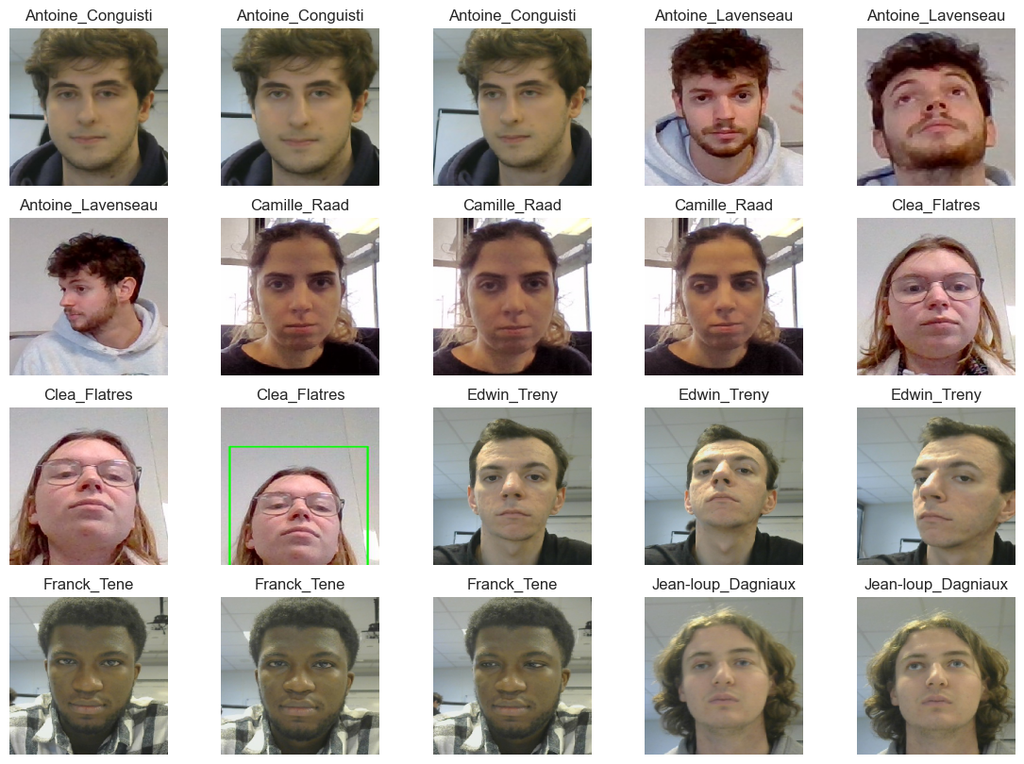

```python
plt.figure(figsize=(14, 10))
for i in range(20):
    plt.subplot(4, 5, i + 1)
    plt.imshow(train_images[i])
    plt.title(class_names[train_labels[i]])  # Utilisation des indices des classes
    plt.axis("off")
plt.show()
```

## Définir le modèle

La prochaine étape consiste à créer notre modèle d’intelligence artificielle basé sur **MobileNetV2**, un réseau de neurones pré-entraîné utilisé pour la reconnaissance d’images. Nous appliquons le transfert d'apprentissage (*transfer learning*) pour l'adapter à notre projet de reconnaissance faciale.

### Résultat :

Une fois cette fonction exécutée, nous obtenons :

- Un modèle d’apprentissage automatique basé sur MobileNetV2, une base solide pour notre projet, car il est à la fois léger et efficace.
- Ce modèle est personnalisé pour reconnaître les visages et peut être entraîné pour des cas d’utilisation spécifiques.

```python
import tensorflow as tf
from tensorflow.keras import layers, models
from tensorflow.keras.applications import MobileNetV2

def build_model(num_classes=num_classes):
    """
    Construit un modèle optimisé pour la reconnaissance faciale basé sur MobileNetV2.

    Arguments :
        num_classes (int) : nombre de classes (personnes à reconnaître)

    Retourne :
        model (tf.keras.Model) : le modèle compilé
    """
    # Charger MobileNetV2 avec une taille d'entrée adaptée aux visages
    base_model = MobileNetV2(input_shape=(224, 224, 3),
                            include_top=False,
                            weights='imagenet')

    # Fine-tuning : dégeler les derniers blocs pour une meilleure adaptation
    # On garde les premiers blocs gelés pour préserver les features bas niveau
    for layer in base_model.layers[-30:]:
        layer.trainable = True

    # Construction du modèle avec des couches optimisées
    model = models.Sequential([
        base_model,
        layers.GlobalAveragePooling2D(),
        # Ajout de dropout pour réduire le surapprentissage
        layers.Dropout(0.5),
        # Couche dense intermédiaire avec activation ReLU
        layers.Dense(512, activation='relu'),
        layers.BatchNormalization(),
        layers.Dropout(0.3),
        # Couche de sortie avec activation softmax pour la classification
        layers.Dense(num_classes, activation='softmax')
    ])

    # Compilation avec des paramètres optimisés
    model.compile(
        optimizer=tf.keras.optimizers.Adam(learning_rate=0.0001),
        loss='categorical_crossentropy',
        metrics=['accuracy', tf.keras.metrics.AUC()]
    )

    model.summary()

    return model

# Exemple d'utilisation
model = build_model()
```

```
Model: "sequential_2"
```

```
┏━━━━━━━━━━━━━━━━━━━━━━━━━━━━━━━━━┳━━━━━━━━━━━━━━━━━━━━━━━━┳━━━━━━━━━━━━━━━┓
┃ Layer (type)                    ┃ Output Shape           ┃       Param # ┃
┡━━━━━━━━━━━━━━━━━━━━━━━━━━━━━━━━━╇━━━━━━━━━━━━━━━━━━━━━━━━╇━━━━━━━━━━━━━━━┩
│ mobilenetv2_1.00_224            │ (None, 7, 7, 1280)     │     2,257,984 │
│ (Functional)                    │                        │               │
├─────────────────────────────────┼────────────────────────┼───────────────┤
│ global_average_pooling2d_2      │ (None, 1280)           │             0 │
│ (GlobalAveragePooling2D)        │                        │               │
├─────────────────────────────────┼────────────────────────┼───────────────┤
│ dropout_4 (Dropout)             │ (None, 1280)           │             0 │
├─────────────────────────────────┼────────────────────────┼───────────────┤
│ dense_4 (Dense)                 │ (None, 512)            │       655,872 │
├─────────────────────────────────┼────────────────────────┼───────────────┤
│ batch_normalization_2           │ (None, 512)            │         2,048 │
│ (BatchNormalization)            │                        │               │
├─────────────────────────────────┼────────────────────────┼───────────────┤
│ dropout_5 (Dropout)             │ (None, 512)            │             0 │
├─────────────────────────────────┼────────────────────────┼───────────────┤
│ dense_5 (Dense)                 │ (None, 18)             │         9,234 │
└─────────────────────────────────┴────────────────────────┴───────────────┘
```

```
 Total params: 2,925,138 (11.16 MB)
```

```
 Trainable params: 2,890,002 (11.02 MB)
```

```
 Non-trainable params: 35,136 (137.25 KB)
```

## Data augmentation et entraînement du modèle

Cette cellule contient une fonction pour **entraîner notre modèle** avec **augmentation de données**, une technique essentielle en apprentissage profond pour améliorer les performances d’un modèle. Voici les étapes principales :

### Fonction `train_model_with_augmentation`

1. **Objectif** :
   - **Entraîner le modèle** que nous avons créé précédemment.
   - **Utiliser l'augmentation de données** pour enrichir les données d'entraînement.
   - **Sauvegarder automatiquement le meilleur modèle** selon les performances de validation.

### Étapes détaillées :

#### **1. Augmentation de données** :

- Nous utilisons la bibliothèque `ImageDataGenerator` pour générer dynamiquement des images modifiées à partir des données d'entraînement.
- Cela améliore la capacité du modèle à généraliser en simulant des variations réalistes dans les images (rotations, décalages, etc.).
- Cette approche est particulièrement utile lorsque la taille du dataset est limitée, comme c'est notre cas.
- Les transformations appliquées incluent :
  - **rotation_range=20** : Les images peuvent être tournées aléatoirement de ±20 degrés.
  - **width_shift_range=0.2 et height_shift_range=0.2** : Les images peuvent être légèrement décalées horizontalement ou verticalement (20 % de leur largeur/hauteur).
  - **horizontal_flip=True** : Les images peuvent être retournées horizontalement.

#### **2. Sauvegarde automatique du meilleur modèle** :

- **Nous définissons** une classe personnalisée `BestModelCheckpoint` :
  - À la fin de chaque époque, elle compare l’accuracy de validation actuelle à la meilleure enregistrée.
  - Si l’accuracy de validation s’améliore, le modèle est sauvegardé dans un fichier nommé `face_recognition_model.keras`.

#### **3. Early stopping** :

- Nous configurons un mécanisme d'arrêt anticipé (`EarlyStopping`) pour arrêter l'entraînement si l'accuracy de validation ne s'améliore pas pendant 5 époques consécutives.
- Cela permet d'éviter un surentraînement et de réduire le temps d'entraînement.

#### **4. Générateurs de données** :

- Nous utilisons les générateurs créés avec `ImageDataGenerator` pour produire les images augmentées par lots (32 images à la fois).

#### **5. Entraînement du modèle** :

- Nous entraînons le modèle sur 50 époques maximum avec les générateurs.
- Les callbacks (`early_stopping` et `best_model_checkpoint`) assurent un entraînement optimisé.

#### **6. Visualisation des résultats** :

- Nous traçons les courbes de perte (`loss`) et d’accuracy (`accuracy`) pour les données d’entraînement et de validation, ce qui nous permet de suivre l'évolution des performances du modèle.

#### **7. Affichage des meilleures performances** :

- Une fois l’entraînement terminé, nous affichons l’époque avec les meilleures performances de validation, avec les scores d’accuracy d’entraînement et de validation.

### Résultat attendu :

1. **Un modèle entraîné** avec des performances optimales sauvegardées dans un fichier (`face_recognition_model.keras`).
2. **Des graphiques** montrant :
   - L’évolution de la perte (loss) au fil des époques.
   - L’évolution de l’accuracy au fil des époques.
3. Une indication des **meilleures performances** atteintes pendant l'entraînement.

```
Époque 4: Nouveau meilleur modèle sauvegardé!
Accuracy d'entraînement: 9.26%
Accuracy de validation: 2.78%

Époque 5: Nouveau meilleur modèle sauvegardé!
Accuracy d'entraînement: 7.41%
Accuracy de validation: 8.33%

Époque 6: Nouveau meilleur modèle sauvegardé!
Accuracy d'entraînement: 11.11%
Accuracy de validation: 11.11%

Époque 7: Nouveau meilleur modèle sauvegardé!
Accuracy d'entraînement: 14.81%
Accuracy de validation: 13.89%

Époque 10: Nouveau meilleur modèle sauvegardé!
Accuracy d'entraînement: 18.52%
Accuracy de validation: 25.00%

Époque 11: Nouveau meilleur modèle sauvegardé!
Accuracy d'entraînement: 29.63%
Accuracy de validation: 27.78%

Époque 13: Nouveau meilleur modèle sauvegardé!
Accuracy d'entraînement: 31.48%
Accuracy de validation: 30.56%

Époque 14: Nouveau meilleur modèle sauvegardé!
Accuracy d'entraînement: 42.59%
Accuracy de validation: 36.11%

Époque 18: Nouveau meilleur modèle sauvegardé!
Accuracy d'entraînement: 64.81%
Accuracy de validation: 47.22%

Époque 20: Nouveau meilleur modèle sauvegardé!
Accuracy d'entraînement: 66.67%
Accuracy de validation: 58.33%

Époque 21: Nouveau meilleur modèle sauvegardé!
Accuracy d'entraînement: 72.22%
Accuracy de validation: 63.89%

Époque 26: Nouveau meilleur modèle sauvegardé!
Accuracy d'entraînement: 85.19%
Accuracy de validation: 72.22%

Époque 29: Nouveau meilleur modèle sauvegardé!
Accuracy d'entraînement: 90.74%
Accuracy de validation: 75.00%

Époque 32: Nouveau meilleur modèle sauvegardé!
Accuracy d'entraînement: 96.30%
Accuracy de validation: 86.11%
Epoch 00037: early stopping
```

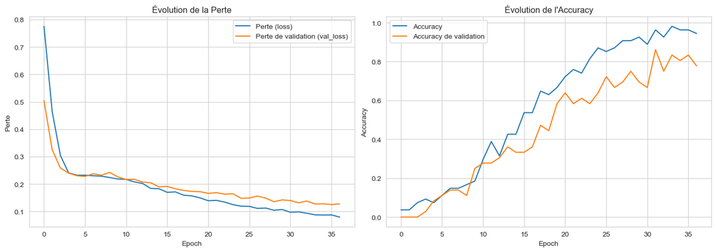

```
Meilleures performances à l'époque 32:
Accuracy d'entraînement: 96.30%
Accuracy de validation: 86.11%
```

```python
def train_model_with_augmentation(model=model, train_images=train_images, train_labels_onehot=train_labels_onehot, val_images=val_images, val_labels_onehot=val_labels_onehot):
    """
    Entraîne un modèle en utilisant l'augmentation de données et sauvegarde le meilleur modèle.

    Arguments :
        model (tf.keras.Model) : modèle à entraîner.
        train_images (numpy.ndarray) : images d'entraînement.
        train_labels_onehot (numpy.ndarray) : labels d'entraînement.
        val_images (numpy.ndarray) : images de validation.
        val_labels_onehot (numpy.ndarray) : labels de validation.
        batch_size (int) : taille du batch pour les générateurs de données.
        epochs (int) : nombre d'époques pour l'entraînement.

    Retourne :
        history (tf.keras.callbacks.History) : objet contenant l'historique de l'entraînement.
    """

    # Data augmentation
    train_datagen = ImageDataGenerator(
        rotation_range=20,
        width_shift_range=0.2,
        height_shift_range=0.2,
        horizontal_flip=True
    )

    # Callback personnalisé pour sauvegarder le meilleur modèle
    class BestModelCheckpoint(tf.keras.callbacks.Callback):
        def __init__(self):
            super().__init__()
            self.best_val_accuracy = 0
            self.best_epoch = 0

        def on_epoch_end(self, epoch, logs=None):
            current_val_accuracy = logs.get('val_accuracy')
            if current_val_accuracy > self.best_val_accuracy:
                self.best_val_accuracy = current_val_accuracy
                self.best_epoch = epoch
                self.model.save("face_recognition_model.keras")
                print(f"\nÉpoque {epoch + 1}: Nouveau meilleur modèle sauvegardé!")
                print(f"Accuracy d'entraînement: {logs.get('accuracy')*100:.2f}%")
                print(f"Accuracy de validation: {current_val_accuracy*100:.2f}%")

    early_stopping = EarlyStopping(
        monitor='val_accuracy',
        patience=5,
        verbose=1,
    )

    best_model_checkpoint = BestModelCheckpoint()

    # Préparer les générateurs de données
    train_generator = train_datagen.flow(train_images, train_labels_onehot, batch_size=32)
    val_generator = train_datagen.flow(val_images, val_labels_onehot, batch_size=32)

    # Entraîner le modèle
    history = model.fit(
        train_generator,
        validation_data=val_generator,
        epochs=50,
        callbacks=[early_stopping, best_model_checkpoint],
        verbose=0
    )

    # Afficher la perte et l'accuracy
    plt.figure(figsize=(14, 5))
    plt.subplot(1, 2, 1)
    plt.plot(history.history['loss'], label='Perte (loss)')
    plt.plot(history.history['val_loss'], label='Perte de validation (val_loss)')
    plt.title('Évolution de la Perte')
    plt.xlabel('Epoch')
    plt.ylabel('Perte')
    plt.legend()

    # Afficher l'accuracy
    plt.subplot(1, 2, 2)
    plt.plot(history.history['accuracy'], label='Accuracy')
    plt.plot(history.history['val_accuracy'], label='Accuracy de validation')
    plt.title('Évolution de l\'Accuracy')
    plt.xlabel('Epoch')
    plt.ylabel('Accuracy')
    plt.legend()

    plt.tight_layout()
    plt.show()

    # Afficher les meilleures performances
    best_epoch = best_model_checkpoint.best_epoch
    print(f"\nMeilleures performances à l'époque {best_epoch + 1}:")
    print(f"Accuracy d'entraînement: {history.history['accuracy'][best_epoch]*100:.2f}%")
    print(f"Accuracy de validation: {history.history['val_accuracy'][best_epoch]*100:.2f}%")

    return model

# Entraîner le modèle avec augmentation de données
model = train_model_with_augmentation()
```

### Analyse des Performances du Modèle de Reconnaissance Faciale

Notre projet de reconnaissance faciale s'inscrit dans le cadre d'un Proof of Concept (POC) avec un objectif initial ambitieux : atteindre un taux de précision d'au moins 85% dans l'identification des étudiants sur une période de 4 semaines.

Les résultats obtenus après l'entraînement du modèle sont particulièrement encourageants. À l'époque 32, nous avons atteint une accuracy d'entraînement de 96.30% et une accuracy de validation de 86.11%, dépassant ainsi notre objectif initial.

L'analyse des courbes d'apprentissage montre une évolution très positive du modèle. La courbe de perte montre une diminution rapide et significative durant les 5 premières époques, suivie d'une stabilisation progressive. La convergence finale vers une valeur de 0.1 pour la perte d'entraînement indique une bonne optimisation du modèle. La faible différence entre les courbes de perte d'entraînement et de validation suggère un léger surapprentissage, qui reste néanmoins dans des limites acceptables.

La progression de l'accuracy est tout aussi satisfaisante. Les courbes montrent une amélioration constante des performances, avec une stabilisation dans les dernières époques. L'écart d'environ 10 points entre l'accuracy d'entraînement et de validation est normal dans ce type d'application et n'impacte pas significativement les performances globales du modèle.

C'est le meilleur modèle que nous avons pu obtenir.

La prochaine cellule contient une fonction complète (**pipeline**) utilisée par l'application finale pour :

1. **Préparer les données** à partir d’un dossier contenant les images organisées par classes.
2. **Construire un modèle** pour la classification.
3. **Entraîner le modèle** en utilisant les données préparées avec augmentation et validation.
4. **Charger le meilleur modèle sauvegardé** après l’entraînement.

```python
def prepare_train_and_evaluate(dataset_path="dataset", img_height=224, img_width=224, train_split=0.6):
    """
    Prépare les datasets, construit le modèle, puis entraîne le modèle avec augmentation de données.

    Arguments :
        dataset_path (str) : chemin vers le dossier contenant les sous-dossiers des classes.
        img_height (int) : hauteur des images après redimensionnement.
        img_width (int) : largeur des images après redimensionnement.
        train_split (float) : fraction des images utilisées pour l'entraînement.
        num_classes (int) : nombre de classes pour la classification.

    Retourne :
        history (tf.keras.callbacks.History) : objet contenant l'historique de l'entraînement.
        model (tf.keras.Model) : le modèle entraîné.
    """
    # Préparation des datasets
    train_images, train_labels, val_images, val_labels, class_names, num_classes, train_labels_onehot, val_labels_onehot = prepare_datasets(
        dataset_path, img_height, img_width, train_split)

    # Construction du modèle
    model = build_model(num_classes)

    # Entraînement du modèle avec augmentation de données
    train_model_with_augmentation(model, train_images, train_labels_onehot, val_images, val_labels_onehot)
    model = tf.keras.models.load_model("face_recognition_model.keras")

    return model

#model = prepare_train_and_evaluate()
```

## Vue d'ensemble des fonctions principales

Une fois que nous avons prepare les données, créer et entrainer nos modèles, nous pouvons initialiser les fonctions pour l'application de reconnaissance faciale et de détection d'objets.

### 1. **detecter_objets**

- Nous avons développé cette fonction qui utilise le modèle YOLO pour détecter les objets spécifiques interdits dans le règlement intérieur.

### 2. **capture_face**

- Cette fonction permet de capturer des images du visage d'une personne dans différentes orientations (face, haut, droite, bas, gauche) à la manière de Face ID pour obtenir l'ensemble des côtés d'un visage et pouvoir le détecter plus facilement sous tous les angles.
- Les images sont sauvegardées dans notre dossier dataset pour entraîner un modèle de reconnaissance faciale.

### 3. **predict_face**

- Cette fonction prédit la classe d'un visage (identité de la personne) en utilisant notre modèle de reconnaissance faciale entrainé plus haut.

Ces fonctions sont au cœur de l'application et permettent de gérer efficacement les tâches de détection et de reconnaissance.

```python
from ultralytics import YOLO
# Charger le modèle sauvegardé
model = tf.keras.models.load_model("face_recognition_model.keras")
class_names = tf.io.gfile.listdir(str('dataset'))

# Initialiser le classificateur de visage d'OpenCV
face_cascade = cv2.CascadeClassifier(cv2.data.haarcascades + 'haarcascade_frontalface_default.xml')

# Dimensions des images attendues
img_height = 224
img_width = 224

OBJETS_SURVEILLES = {
    'Sunglasses': 505,
    'Hat': 243,
    'Shorts': 456,
    'Skirt': 463,
    'Miniskirt': 334,
    'Helmet': 248,
    'Kitchen Knife': 292,
    'Shotgun': 457,
    'Handgun': 238
}

def charger_modele_yolo():
    """Charge le modèle YOLO"""
    # Désactiver les logs de YOLO
    logging.getLogger("ultralytics").setLevel(logging.WARNING)
    return YOLO("yolov8n-oiv7.pt", verbose=False)

def detecter_objets(frame, model_yolo):
    """Détecte les objets interdits dans la frame"""
    # Désactiver la sortie stdout temporairement
    old_stdout = sys.stdout
    sys.stdout = open(os.devnull, 'w')

    results = model_yolo(frame, verbose=False)

    # Restaurer la sortie stdout
    sys.stdout = old_stdout

    detections = []

    for r in results:
        boxes = r.boxes
        for box in boxes:
            cls_id = int(box.cls[0])
            for nom_objet, id_classe in OBJETS_SURVEILLES.items():
                if cls_id == id_classe:
                    x1, y1, x2, y2 = box.xyxy[0]
                    confidence = float(box.conf[0])
                    if confidence > 0.4:
                        detections.append({
                            'objet': nom_objet,
                            'confiance': confidence,
                            'coords': (int(x1), int(y1), int(x2), int(y2))
                        })
    return detections

# Fonction pour effectuer une prédiction
def capture_face(prenom, nom):
    # Créer le dossier pour enregistrer les images si il n'existe pas
    folder_name = f"dataset/{prenom.capitalize()} {nom.capitalize()}"
    if not os.path.exists(folder_name):
        os.makedirs(folder_name)

    # Ouvrir la caméra
    cap = cv2.VideoCapture(0)
    captured_images = 0
    directions = ["Regardez en face", "Regardez en haut", "Regardez vers la droite", "Regardez en bas", "Regardez vers la gauche"]
    images_per_direction = 1  # Nombre d'images par direction
    total_images = len(directions) * images_per_direction

    direction_index = 0

    while captured_images < total_images:
        # Récupérer l'étape actuelle sans print
        current_direction = directions[direction_index]

        # Pause de 3 secondes avec affichage de l'étape actuelle
        for i in range(3, 0, -1):
            ret, frame = cap.read()
            if not ret:
                break
            # Ajouter le texte pour guider l'utilisateur
            cv2.putText(frame, f"{current_direction} dans {i} secondes",
                        (10, 50), cv2.FONT_HERSHEY_SIMPLEX, 1, (0, 255, 255), 2)
            cv2.imshow('Capturer le visage', frame)
            cv2.waitKey(1000)

        while captured_images < (direction_index + 1) * images_per_direction:
            ret, frame = cap.read()
            if not ret:
                break

            # Convertir en niveaux de gris pour la détection
            gray = cv2.cvtColor(frame, cv2.COLOR_BGR2GRAY)

            # Détection des visages
            faces = face_cascade.detectMultiScale(gray, scaleFactor=1.1, minNeighbors=5, minSize=(30, 30))

            for (x, y, w, h) in faces:
                # Élargir la zone pour prendre toute la tête
                x_head = max(0, x - int(0.2 * w))  # 20% de plus sur les côtés
                y_head = max(0, y - int(0.3 * h))  # 30% de plus en haut pour inclure plus de tête
                w_head = min(frame.shape[1] - x_head, int(w * 1.4))  # Largeur augmentée
                h_head = min(frame.shape[0] - y_head, int(h * 1.6))  # Hauteur augmentée

                # Extraire toute la tête
                head = frame[y_head:y_head+h_head, x_head:x_head+w_head]

                # Enregistrer l'image
                head_filename = f"{folder_name}/head_{captured_images}.jpg"
                cv2.imwrite(head_filename, head)
                captured_images += 1

                # Ajouter un rectangle et des informations à l'écran
                cv2.putText(frame, f"Image {captured_images}/{total_images}",
                            (10, 30), cv2.FONT_HERSHEY_SIMPLEX, 1, (0, 255, 0), 2)
                cv2.rectangle(frame, (x_head, y_head), (x_head+w_head, y_head+h_head), (0, 255, 0), 2)

            # Afficher l'étape actuelle pendant la capture
            cv2.putText(frame, f"Etape actuelle : {current_direction}",
                        (10, frame.shape[0] - 20), cv2.FONT_HERSHEY_SIMPLEX, 1, (255, 255, 0), 2)

            # Afficher le flux vidéo avec les visages détectés
            cv2.imshow('Capturer le visage', frame)

            # Quitter avec la touche 'q'
            if cv2.waitKey(1) & 0xFF == ord('q'):
                cap.release()
                cv2.destroyAllWindows()
                return

        # Passer à la prochaine direction
        direction_index = (direction_index + 1) % len(directions)

    # Libérer les ressources
    cap.release()
    cv2.destroyAllWindows()
    show_message(f"Enregistrement du visage terminé. Veuillez entrainer le modèle.")


# Fonction pour effectuer une prédiction
def predict_face(face, model, class_names, threshold=0.6):
    """
    Prédit la classe d'un visage et vérifie s'il est inconnu.
    Args:
        face: Image du visage.
        model: Modèle de reconnaissance faciale.
        class_names: Liste des noms de classes.
        threshold: Seuil de confiance pour les visages inconnus.

    Returns:
        predicted_class: Nom de la classe prédite ou 'Inconnu'.
        confidence: Confiance de la prédiction.
    """
    face = cv2.resize(face, (img_width, img_height))  # Redimensionner
    face_array = img_to_array(face) / 255.0  # Normaliser
    face_array = np.expand_dims(face_array, axis=0)  # Ajouter une dimension batch

    # Obtenir les prédictions (logits)
    probabilities = model.predict(face_array, verbose=0)[0]  # Sortie du modèle
    softmax_p = np.exp(probabilities) / np.sum(np.exp(probabilities), axis=-1)  # Probabilités softmax

    # Obtenir la classe avec la probabilité maximale
    max_index = np.argmax(softmax_p)
    confidence = expit(probabilities[max_index])

    # Vérifier si le visage est inconnu
    if confidence < threshold:
        return "Inconnu", confidence
    else:
        predicted_class = class_names[max_index]
        return predicted_class, confidence

def show_message(message, duration=5):
    """
    Affiche un message dans une fenêtre pendant une durée spécifiée.
    """
    root = Tk()
    root.title("Prochaine étape")
    root.geometry("300x100")
    label = Label(root, text=message, font=("Helvetica", 16), wraplength=280)
    label.pack(expand=True)
    root.after(duration * 1000, root.destroy)  # Ferme la fenêtre après `duration` secondes
    root.mainloop()
```

On va analyser des images ou des vidéos pour détecter des visages et des objets à l'aide de plusieurs modèles d'apprentissage automatique. Nous utilisons YOLO pour la détection d'objets, notre modèle pour la reconnaissance faciale, et notre modèle de captioning (crée dans "captioning1.ipynb") pour générer une description de l'image. On combine ensuite la détection de visages et d'objets avec la génération automatique de descriptions d'images. Notre code est conçu pour fonctionner à la fois avec des images pré-existantes et des flux vidéo en temps réel, tout en enregistrant les événements dans un fichier de logs pour un suivi ultérieur sur Power BI.

### Fonction principale : `analyze_face(camera_mode, image_path=None)`

Cette fonction nous permet d'analyser une image ou un flux vidéo en détectant des visages et des objets, et génère une description de l'image.

### Cas d'utilisation

- Si on nous fournit un `image_path`, nous traitons l'image spécifiée.
- Si aucun `image_path` n'est fourni, on utilise la caméra en temps réel pour analyser les visages et les objets.

```python
import textwrap
def analyze_face(camera_mode, image_path=None):
    """
    Analyse les visages, objets et génère une description de l'image
    Args:
        camera_mode: Mode de la caméra ("Entree" ou "Sortie")
        image_path: Chemin de l'image à analyser. Si None, utilise la caméra
    """
    log_file = "face_detection_logs.csv"
    model_yolo = charger_modele_yolo()

    # Initialisation du modèle de captioning
    caption_model = tf.keras.models.load_model('caption_model.keras')
    with open('tokenizer.pkl', 'rb') as f:
        data = pickle.load(f)
        tokenizer = data['tokenizer']
        max_length = data['max_length']

    # Configuration du modèle DenseNet
    model_densenet = DenseNet201()
    feature_extractor = tf.keras.Model(inputs=model_densenet.input,
                                     outputs=model_densenet.layers[-2].output)

    if not os.path.exists(log_file):
        with open(log_file, 'w', newline='') as f:
            writer = csv.writer(f)
            writer.writerow(['Date', 'Heure', 'Personne', 'Objets_Interdits', 'Mode', 'Description'])

    last_person_state = {}

    def generate_image_caption(image):
        # Redimensionner l'image pour DenseNet
        img_array = cv2.resize(image, (224, 224))
        img_array = cv2.cvtColor(img_array, cv2.COLOR_BGR2RGB)
        img_array = img_array / 255.
        img_array = np.expand_dims(img_array, axis=0)

        # Extraire les caractéristiques
        feature = feature_extractor.predict(img_array, verbose=0)

        # Générer la description
        in_text = "startseq"
        for i in range(max_length):
            sequence = tokenizer.texts_to_sequences([in_text])[0]
            sequence = pad_sequences([sequence], maxlen=max_length)

            try:
                y_pred = caption_model.predict([feature, sequence], verbose=0)
                y_pred = np.argmax(y_pred)

                word = next((word for word, index in tokenizer.word_index.items()
                           if index == y_pred), None)

                if word is None:
                    break

                in_text += " " + word

                if word == 'endseq':
                    break
            except Exception as e:
                print(f"Erreur lors de la génération de la description: {str(e)}")
                return "Impossible de générer une description"

        return in_text.replace('startseq', '').replace('endseq', '').strip()

    if image_path:
        frame = cv2.imread(image_path)
        if frame is None:
            messagebox.showerror("Erreur", "Impossible de charger l'image")
            return

        # Générer la description de l'image
        description = generate_image_caption(frame)

        while True:
            display_frame = frame.copy()
            detections_objets = detecter_objets(frame, model_yolo)
            gray = cv2.cvtColor(frame, cv2.COLOR_BGR2GRAY)
            faces = face_cascade.detectMultiScale(gray, scaleFactor=1.1, minNeighbors=5, minSize=(30, 30))

            objets_detectes = [f"{det['objet']} ({det['confiance']:.2f})" for det in detections_objets]

            for (x, y, w, h) in faces:
                x_head = max(0, x - int(0.2 * w))
                y_head = max(0, y - int(0.3 * h))
                w_head = min(frame.shape[1] - x_head, int(w * 1.4))
                h_head = min(frame.shape[0] - y_head, int(h * 1.6))

                head = frame[y_head:y_head+h_head, x_head:x_head+w_head]
                predicted_class, confidence = predict_face(head, model, class_names)

                if predicted_class not in last_person_state or last_person_state[predicted_class] != camera_mode:
                    now = datetime.now()
                    date_str = now.strftime("%Y-%m-%d")
                    time_str = now.strftime("%H:%M:%S")
                    with open(log_file, 'a', newline='') as f:
                        writer = csv.writer(f)
                        writer.writerow([date_str, time_str, predicted_class,
                                       ', '.join(objets_detectes), camera_mode, description])

                    last_person_state[predicted_class] = camera_mode

                color = (0, 255, 0) if predicted_class != "Inconnu" else (0, 0, 255)
                text = f"{predicted_class} {confidence*100:.2f}%" if predicted_class != "Inconnu" else "Visage Inconnu"

                cv2.rectangle(display_frame, (x_head, y_head), (x_head+w_head, y_head+h_head), color, 2)
                cv2.putText(display_frame, text, (x_head, y_head - 10), cv2.FONT_HERSHEY_SIMPLEX, 0.8, color, 2)

            # Afficher la description sur l'image
            desc_lines = textwrap.wrap(description, width=40)
            y_pos = 30
            for line in desc_lines:
                # Obtenir la taille du texte pour créer le rectangle de fond
                (text_width, text_height), _ = cv2.getTextSize(line, cv2.FONT_HERSHEY_SIMPLEX, 0.6, 1)

                # Dessiner un rectangle blanc comme fond
                cv2.rectangle(display_frame,
                             (5, y_pos - text_height - 5),  # Point supérieur gauche
                             (15 + text_width, y_pos + 5),   # Point inférieur droit
                             (255, 255, 255),                # Couleur du fond (blanc)
                             -1)                             # -1 pour remplir le rectangle

                # Dessiner le texte noir avec épaisseur normale
                cv2.putText(display_frame, line, (10, y_pos),
                           cv2.FONT_HERSHEY_SIMPLEX, 0.6, (0, 0, 0), 1)  # épaisseur changée à 1

                y_pos += 25

            for det in detections_objets:
                x1, y1, x2, y2 = det['coords']
                nom = f"{det['objet']} {det['confiance']:.2f}"
                cv2.rectangle(display_frame, (x1, y1), (x2, y2), (0, 0, 255), 2)
                cv2.putText(display_frame, nom, (x1, y1-10), cv2.FONT_HERSHEY_SIMPLEX, 0.7, (0, 0, 255), 2)

            cv2.imshow('Analyse d\'image', display_frame)

            if cv2.waitKey(1) & 0xFF == ord('q'):
                break

    else:
        cap = cv2.VideoCapture(0)
        while True:
            ret, frame = cap.read()
            if not ret:
                break

            detections_objets = detecter_objets(frame, model_yolo)
            gray = cv2.cvtColor(frame, cv2.COLOR_BGR2GRAY)
            faces = face_cascade.detectMultiScale(gray, scaleFactor=1.1, minNeighbors=5, minSize=(30, 30))

            current_time = time.time()
            objets_detectes = [f"{det['objet']} ({det['confiance']:.2f})" for det in detections_objets]

            for (x, y, w, h) in faces:
                x_head = max(0, x - int(0.2 * w))
                y_head = max(0, y - int(0.3 * h))
                w_head = min(frame.shape[1] - x_head, int(w * 1.4))
                h_head = min(frame.shape[0] - y_head, int(h * 1.6))

                head = frame[y_head:y_head+h_head, x_head:x_head+w_head]
                predicted_class, confidence = predict_face(head, model, class_names)

                if (predicted_class not in last_person_state or last_person_state[predicted_class] != camera_mode) or \
                   (current_time - last_log_time >= 60):
                    now = datetime.now()
                    with open(log_file, 'a', newline='') as f:
                        writer = csv.writer(f)
                        writer.writerow([
                            now.strftime("%Y-%m-%d"),
                            now.strftime("%H:%M:%S"),
                            predicted_class,
                            ', '.join(objets_detectes),
                            camera_mode,
                        ])

                    last_person_state[predicted_class] = camera_mode
                    last_log_time = current_time

                color = (0, 255, 0) if predicted_class != "Inconnu" else (0, 0, 255)
                text = f"{predicted_class} {confidence*100:.2f}%" if predicted_class != "Inconnu" else "Visage Inconnu"

                cv2.rectangle(frame, (x_head, y_head), (x_head+w_head, y_head+h_head), color, 2)
                cv2.putText(frame, text, (x_head, y_head - 10), cv2.FONT_HERSHEY_SIMPLEX, 0.8, color, 2)

            for det in detections_objets:
                x1, y1, x2, y2 = det['coords']
                nom = f"{det['objet']} {det['confiance']:.2f}"
                cv2.rectangle(frame, (x1, y1), (x2, y2), (0, 0, 255), 2)
                cv2.putText(frame, nom, (x1, y1-10), cv2.FONT_HERSHEY_SIMPLEX, 0.7, (0, 0, 255), 2)

            cv2.imshow('Reconnaissance Faciale et Detection d\'objets', frame)

            if cv2.waitKey(1) & 0xFF == ord('q'):
                break

        cap.release()

    cv2.destroyAllWindows()
```

Enfin, nous créons une interface graphique permettant de gérer l'authentification et d'effectuer des actions liées à la reconnaissance faciale et à l'analyse d'images.

#### Fonctionnalités principales :

1. **Authentification de l'utilisateur** :
   - L'utilisateur doit entrer un mot de passe pour accéder à l'application.
   - L'utilisateur peut aussi choisir un mode caméra (par exemple, "Entrée" ou "Sortie").
2. **Interface principale** :
   - Après une authentification réussie, l'utilisateur accède à une interface principale avec plusieurs fonctionnalités :
     - Enregistrer un visage pour la reconnaissance faciale.
     - Analyser une image ou utiliser la caméra pour effectuer de la reconnaissance faciale.
     - Modifier son mot de passe ou se déconnecter de l'application.
3. **Gestion du mot de passe** :
   - Le mot de passe est sécurisé et stocké dans un fichier.
   - L'utilisateur peut changer son mot de passe via l'interface

```python
def check_password_and_mode(root, password_manager):
    dialog = tk.Toplevel(root)
    dialog.title("Authentification")
    dialog.grab_set()

    password_var = tk.StringVar()
    mode_var = tk.StringVar(value="Entree")
    result = {'authenticated': False, 'mode': None}

    frame = tk.Frame(dialog, padx=20, pady=20)
    frame.pack(expand=True, fill='both')

    tk.Label(frame, text="Mot de passe:").pack(pady=5)
    password_entry = tk.Entry(frame, show="*", textvariable=password_var)
    password_entry.pack(pady=5)

    tk.Label(frame, text="Mode caméra:").pack(pady=5)
    tk.Radiobutton(frame, text="Entrée", variable=mode_var, value="Entree").pack()
    tk.Radiobutton(frame, text="Sortie", variable=mode_var, value="Sortie").pack()

    def validate():
        if password_manager.verify_password(password_var.get()):
            result['authenticated'] = True
            result['mode'] = mode_var.get()
            dialog.destroy()
        else:
            messagebox.showerror("Erreur", "Mot de passe incorrect")

    def on_close():
        result['authenticated'] = False
        dialog.destroy()

    button_frame = tk.Frame(frame)
    button_frame.pack(pady=10)

    tk.Button(button_frame, text="Valider", command=validate).pack(side=tk.LEFT, padx=5)
    tk.Button(button_frame, text="Annuler", command=on_close).pack(side=tk.LEFT, padx=5)

    dialog.protocol("WM_DELETE_WINDOW", on_close)

    # Centrer la fenêtre
    dialog.update_idletasks()
    width = dialog.winfo_width()
    height = dialog.winfo_height()
    x = (dialog.winfo_screenwidth() // 2) - (width // 2)
    y = (dialog.winfo_screenheight() // 2) - (height // 2)
    dialog.geometry('{}x{}+{}+{}'.format(width, height, x, y))

    dialog.wait_window()
    return result

def create_authenticated_interface(root, password_manager, camera_mode):
    root.deiconify()
    # Nettoyer la fenêtre principale
    for widget in root.winfo_children():
        widget.destroy()

    root.title("Reconnaissance Faciale et Description d'Images")

    # Frame principale avec scrollbar
    main_frame = ttk.Frame(root)
    main_frame.pack(expand=True, fill='both', padx=10, pady=10)

    # Variable pour stocker la dernière description générée
    description_var = tk.StringVar()

    def logout():
        root.withdraw()
        show_login_screen(root)

    def start_capture():
        prenom = simpledialog.askstring("Prénom", "Entrez votre prénom:")
        nom = simpledialog.askstring("Nom", "Entrez votre nom:")
        if prenom and nom:
            capture_face(prenom, nom)

    def change_password_dialog():
        old_pwd = simpledialog.askstring("Changement de mot de passe", "Ancien mot de passe:", show='*')
        new_pwd = simpledialog.askstring("Changement de mot de passe", "Nouveau mot de passe:", show='*')
        if old_pwd and new_pwd:
            if password_manager.change_password(old_pwd, new_pwd):
                messagebox.showinfo("Succès", "Mot de passe modifié avec succès")
            else:
                messagebox.showerror("Erreur", "Impossible de modifier le mot de passe")

    def start_analyze_face():
        analyze_face(camera_mode)

    def start_analyze_image():
        file_path = filedialog.askopenfilename(
            title="Sélectionner une image",
            filetypes=(("Images", "*.jpg *.jpeg *.png"), ("Tous les fichiers", "*.*"))
        )
        if file_path:
            # Mettre à jour le label pour indiquer que l'analyse est en cours
            status_label.config(text="Analyse en cours...")
            root.update()

            # Lancer l'analyse
            analyze_face(camera_mode, image_path=file_path)

            # Lire la dernière ligne du fichier log pour obtenir la description
            try:
                with open('face_detection_logs.csv', 'r', newline='') as f:
                    last_line = list(csv.reader(f))[-1]
                    description = last_line[-1]  # La description est dans la dernière colonne
                    description_var.set(description)
                    status_label.config(text="Analyse terminée")
            except Exception as e:
                description_var.set("Impossible de récupérer la description")
                status_label.config(text="Erreur lors de l'analyse")

    # Création des widgets
    title_label = ttk.Label(main_frame, text="Système de Reconnaissance et Description", font=('Helvetica', 14, 'bold'))
    title_label.pack(pady=10)

    status_label = ttk.Label(main_frame, text="")
    status_label.pack()

    # Boutons pour chaque fonctionnalité
    capture_button = ttk.Button(main_frame, text="Enregistrer un visage", command=start_capture)
    capture_button.pack(pady=5)

    train_button = ttk.Button(main_frame, text="Entrainer le modèle", command=prepare_train_and_evaluate)
    train_button.pack(pady=5)

    image_button = ttk.Button(main_frame, text="Analyser une image", command=start_analyze_image)
    image_button.pack(pady=5)

    camera_button = ttk.Button(main_frame, text="Reconnaissance faciale", command=start_analyze_face)
    camera_button.pack(pady=5)

    # Frame pour la description
    description_frame = ttk.LabelFrame(main_frame, text="Description de l'image")
    description_frame.pack(pady=10, padx=5, fill='x')

    description_label = ttk.Label(description_frame,
                                textvariable=description_var,
                                wraplength=400,
                                justify='left')
    description_label.pack(pady=5, padx=5)

    # Boutons administratifs en bas
    admin_frame = ttk.Frame(main_frame)
    admin_frame.pack(side='bottom', pady=10)

    change_pwd_button = ttk.Button(admin_frame, text="Changer le mot de passe", command=change_password_dialog)
    change_pwd_button.pack(side='left', padx=5)

    logout_button = ttk.Button(admin_frame, text="Se déconnecter", command=logout)
    logout_button.pack(side='left', padx=5)

    mode_label = ttk.Label(admin_frame, text=f"Mode caméra: {camera_mode}")
    mode_label.pack(side='left', padx=5)

def create_password_manager():
    class PasswordManager:
        def __init__(self, config_file='password_config.json'):
            self.config_file = config_file
            self.current_password = None
            self.load_password()

        def hash_password(self, password):
            return hashlib.sha256(password.encode()).hexdigest()

        def load_password(self):
            if os.path.exists(self.config_file):
                with open(self.config_file, 'r') as f:
                    config = json.load(f)
                    self.current_password = config.get('password')

            # Si aucun mot de passe n'existe, définir un mot de passe par défaut
            if not self.current_password:
                default_password = self.hash_password('admin')
                self.save_password(default_password)

        def save_password(self, hashed_password):
            with open(self.config_file, 'w') as f:
                json.dump({'password': hashed_password}, f)
            self.current_password = hashed_password

        def verify_password(self, input_password):
            hashed_input = self.hash_password(input_password)
            return hashed_input == self.current_password

        def change_password(self, old_password, new_password):
            if self.verify_password(old_password):
                new_hashed_password = self.hash_password(new_password)
                self.save_password(new_hashed_password)
                return True
            return False

    return PasswordManager()

def check_password(password_manager):
    input_password = simpledialog.askstring("Authentification", "Entrez le mot de passe:", show='*')
    return password_manager.verify_password(input_password)

# Lancer l'application
def show_login_screen(root):
    password_manager = create_password_manager()

    while True:
        result = check_password_and_mode(root, password_manager)
        if result['authenticated']:
            create_authenticated_interface(root, password_manager, result['mode'])
            break
        else:
            retry = messagebox.askretrycancel("Erreur", "Authentification annulée")
            if not retry:
                root.quit()
                break

def start_application():
    root = tk.Tk()
    root.title("Login")

    # Définir une taille minimale pour la fenêtre principale
    root.minsize(450, 150)

    # Centrer la fenêtre principale
    width = 300
    height = 400
    x = (root.winfo_screenwidth() // 2) - (width // 2)
    y = (root.winfo_screenheight() // 2) - (height // 2)
    root.geometry(f'{width}x{height}+{x}+{y}')

    # Masquer la fenêtre principale au démarrage
    root.withdraw()

    show_login_screen(root)
    root.mainloop()

if __name__ == "__main__":
    start_application()
```

## Conclusion

L'un des points forts de notre solution est sa capacité à effectuer des analyses en temps réel sur les personnes se trouvant devant la caméra, tout en permettant également l'analyse d'images avec détection simultanée de plusieurs individus. La possibilité d'ajouter de nouveaux visages au système, similaire au Face ID, rend l'application évolutive et adaptable aux besoins changeants des utilisateurs.

Ces réalisations démontrent notre capacité à mener à bien un projet technique complexe, en combinant différentes technologies d'intelligence artificielle pour créer une solution fonctionnelle et performante. Les compétences acquises durant ce projet, tant en programmation qu'en machine learning, constituent une base solide pour nos futurs développements dans le domaine de l'intelligence artificielle.

Bien que notre application soit déjà fonctionnelle et performante, plusieurs axes d'amélioration pourraient être envisagés pour des développements futurs. Nous pourrions travailler sur l'optimisation de notre modèle pour augmenter sa précision au-delà des 86% actuels. Notre système de captioning nécessite également des améliorations significatives, particulièrement dans la reconnaissance des couleurs et des types de vêtements où nous observons encore un taux d'erreur important. L'ajout d'un système de suivi des déplacements des personnes dans l'espace permettrait d'enrichir les fonctionnalités de sécurité. Il serait également intéressant d'implémenter un système de notification en temps réel en cas de détection d'une personne non autorisée. Enfin, le développement d'une version mobile de l'application pourrait offrir plus de flexibilité aux utilisateurs et administrateurs du système.